# Regularization

Joshua Eubanks

2022-07-25

```r
library(gamlr)
```

Regularization is essentially another way to say desensitization. What we will do is trade off bias (deviations from minimizing SSR) and variance (variation in predicted values).

# 1 Examples

We are going to go through multiple examples.

## 1.1 NHL

The data comprise of information about play configuration and the players on ice (including goalies) for every goal from 2002-03 to 2012-14 NHL seasons. Collected using A. C. Thomas’s `nlhscrapr` package. See the Chicago hockey analytics project at `github.com/mataddy/hockey`

- goal -> Info about each goal scored, including homegoal – an indicator for the home team scoring.
- player -> Sparse Matrix with entries for who was on the ice for each goal: +1 for a home team player, -1 for an away team player, zero otherwise.
- team -> Sparse Matrix with indicators for each team*season interaction: +1 for home team, -1 for away team.
- config -> Special teams info. For example, S5v4 is a 5 on 4 powerplay, +1 if it is for the home-team and -1 for the away team

### 1.1.1 Data Cleaning

Bringing in data

```r
data(hockey)
```

#### 1.1.1.1 Generate Independent Variables

```r
x <- cbind(config,team,player) # cbind binds together two sparse matrices
```

#### 1.1.1.2 Generating dependent variable, Binary response

```r
y <- goal$homegoal
```

### 1.1.2 Generate Model

```r
nhlreg <- gamlr(x, y, verb=TRUE,
    free=1:(ncol(config)+ncol(team)), ## free denotes unpenalized columns
    family="binomial", standardize=FALSE)
```

```
## *** n=69449 observations and p=2776 covariates ***
## segment 1: lambda = 0.001289, dev = 8.096e+04, npass = 292
## segment 2: lambda = 0.001231, dev = 8.095e+04, npass = 3
## segment 3: lambda = 0.001175, dev = 8.094e+04, npass = 3
## segment 4: lambda = 0.001121, dev = 8.094e+04, npass = 3
## segment 5: lambda = 0.00107, dev = 8.093e+04, npass = 4
## segment 6: lambda = 0.001022, dev = 8.092e+04, npass = 4
## segment 7: lambda = 0.0009753, dev = 8.091e+04, npass = 3
## segment 8: lambda = 0.000931, dev = 8.089e+04, npass = 3
## segment 9: lambda = 0.0008887, dev = 8.087e+04, npass = 4
## segment 10: lambda = 0.0008483, dev = 8.084e+04, npass = 4
## segment 11: lambda = 0.0008097, dev = 8.081e+04, npass = 4
## segment 12: lambda = 0.0007729, dev = 8.079e+04, npass = 4
## segment 13: lambda = 0.0007378, dev = 8.076e+04, npass = 4
## segment 14: lambda = 0.0007043, dev = 8.073e+04, npass = 4
## segment 15: lambda = 0.0006723, dev = 8.07e+04, npass = 4
## segment 16: lambda = 0.0006417, dev = 8.066e+04, npass = 4
## segment 17: lambda = 0.0006125, dev = 8.063e+04, npass = 4
## segment 18: lambda = 0.0005847, dev = 8.059e+04, npass = 4
## segment 19: lambda = 0.0005581, dev = 8.055e+04, npass = 4
## segment 20: lambda = 0.0005327, dev = 8.051e+04, npass = 4
## segment 21: lambda = 0.0005085, dev = 8.046e+04, npass = 4
## segment 22: lambda = 0.0004854, dev = 8.041e+04, npass = 4
## segment 23: lambda = 0.0004634, dev = 8.036e+04, npass = 4
## segment 24: lambda = 0.0004423, dev = 8.031e+04, npass = 4
## segment 25: lambda = 0.0004222, dev = 8.025e+04, npass = 4
## segment 26: lambda = 0.000403, dev = 8.019e+04, npass = 4
## segment 27: lambda = 0.0003847, dev = 8.013e+04, npass = 4
## segment 28: lambda = 0.0003672, dev = 8.007e+04, npass = 4
## segment 29: lambda = 0.0003505, dev = 8.001e+04, npass = 4
## segment 30: lambda = 0.0003346, dev = 7.995e+04, npass = 4
## segment 31: lambda = 0.0003194, dev = 7.99e+04, npass = 4
## segment 32: lambda = 0.0003049, dev = 7.984e+04, npass = 4
## segment 33: lambda = 0.000291, dev = 7.978e+04, npass = 4
## segment 34: lambda = 0.0002778, dev = 7.972e+04, npass = 4
## segment 35: lambda = 0.0002651, dev = 7.967e+04, npass = 4
## segment 36: lambda = 0.0002531, dev = 7.961e+04, npass = 4
## segment 37: lambda = 0.0002416, dev = 7.955e+04, npass = 4
## segment 38: lambda = 0.0002306, dev = 7.949e+04, npass = 4
## segment 39: lambda = 0.0002201, dev = 7.943e+04, npass = 4
```

[output cut: 46 more lines]

```
## segment 86: lambda = 2.473e-05, dev = 7.707e+04, npass = 3
## segment 87: lambda = 2.36e-05, dev = 7.703e+04, npass = 3
## segment 88: lambda = 2.253e-05, dev = 7.7e+04, npass = 3
## segment 89: lambda = 2.151e-05, dev = 7.697e+04, npass = 1
## segment 90: lambda = 2.053e-05, dev = 7.695e+04, npass = 1
## segment 91: lambda = 1.96e-05, dev = 7.691e+04, npass = 3
## segment 92: lambda = 1.871e-05, dev = 7.688e+04, npass = 3
## segment 93: lambda = 1.786e-05, dev = 7.685e+04, npass = 3
## segment 94: lambda = 1.704e-05, dev = 7.683e+04, npass = 1
## segment 95: lambda = 1.627e-05, dev = 7.68e+04, npass = 1
## segment 96: lambda = 1.553e-05, dev = 7.678e+04, npass = 1
## segment 97: lambda = 1.482e-05, dev = 7.676e+04, npass = 1
## segment 98: lambda = 1.415e-05, dev = 7.672e+04, npass = 3
## segment 99: lambda = 1.351e-05, dev = 7.67e+04, npass = 3
## segment 100: lambda = 1.289e-05, dev = 7.667e+04, npass = 3
```

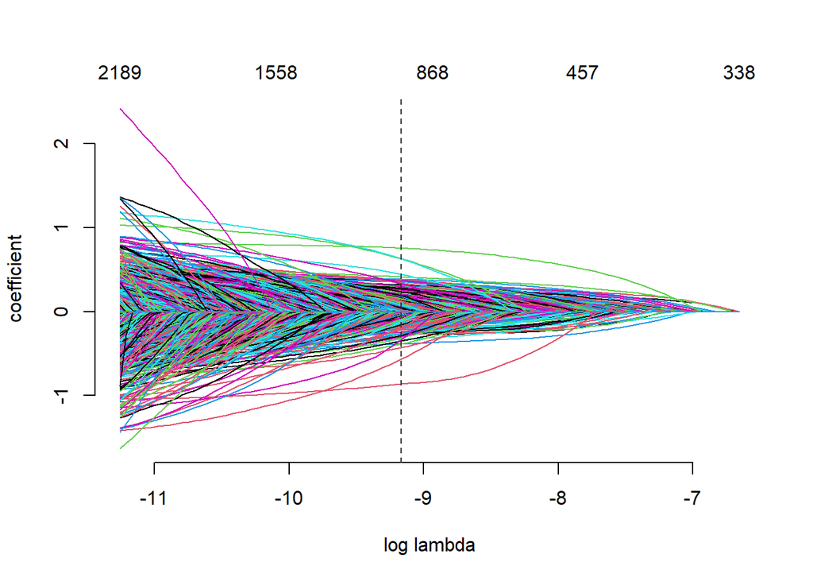

```r
plot(nhlreg)
```

#### 1.1.2.1 Extracting Coefficents

Let’s grab the coefficients of each player

```r
# AICc selection
Baicc <- coef(nhlreg)[colnames(player),]
```

First, a simple gut-check point: the intercept. This is the effect on odds that a goal is home rather than away, regardless of any info about what teams are playing or who is on ice. It’s the home ice advantage!

We find that home-ice increases odds you’ve scored by 8%

```r
100*(exp(coef(nhlreg)[1])-1)
```

```
## [1] 8.235434
```

Now, lets look at the player effects. The regression finds 646 significant player effects

```r
sum(Baicc!=0)
```

```
## [1] 646
```

Here are the top 10 players

```r
Baicc[order(Baicc, decreasing=TRUE)[1:10]]
```

```
## PETER_FORSBERG  TYLER_TOFFOLI   ONDREJ_PALAT ZIGMUND_PALFFY  SIDNEY_CROSBY
##      0.7548254      0.6292577      0.6284040      0.4426997      0.4131174
##   JOE_THORNTON  PAVEL_DATSYUK  LOGAN_COUTURE      ERIC_FEHR MARTIN_GELINAS
##      0.3837632      0.3761981      0.3682103      0.3677283      0.3577613
```

Here are the bottom 10

```r
Baicc[order(Baicc)[1:10]]
```

```
##     TIM_TAYLOR  JOHN_MCCARTHY P. J._AXELSSON NICLAS_HAVELID    THOMAS_POCK
##     -0.8643214     -0.5651886     -0.4283811     -0.3854583     -0.3844128
##  MATHIEU_BIRON  CHRIS_DINGMAN   DARROLL_POWE RAITIS_IVANANS   RYAN_HOLLWEG
##     -0.3512101     -0.3342243     -0.3339906     -0.3129481     -0.2988769
```

Specifically, the model says, e.g., that whenever a goal is scored, Pittsburgh’s odds of having scored (rather than scored on) increase by a 51% if Sidney Crosby is on the ice.

```r
exp(Baicc["SIDNEY_CROSBY"])
```

```
## SIDNEY_CROSBY
##      1.511523
```

And the Blue Jackets (or Kings, pre 2011-12) odds of having scored drop by around 22% if Jack Johnson is on the ice.

```r
exp(Baicc["JACK_JOHNSON"])
```

```
## JACK_JOHNSON
##    0.7813488
```

hockey fans among you may feel free to comment in much more detail.

### 1.1.3 Standardizing vs Not Standardizing Data

Without `standardize=FALSE`, you’d be multiplying the penalty for each coefficient (player effect) by that player’s standard deviation in onice. The players with big SD in onice are guys who play a lot. Players with small SD are those who play little (almost all zeros). So weighting penalty by SD in this case is exactly what you don’t want: a bigger penalty for people with many minutes on ice, a smaller penalty for those who seldom play. Indeed, running the regression without `standardize=FALSE` leads to a bunch of farm teamers coming up tops.

```r
nhlreg.std <-  gamlr(x, y,
    free=1:(ncol(config)+ncol(team)), family="binomial")
Bstd <- coef(nhlreg.std)[colnames(player),]
Bstd[order(Bstd, decreasing=TRUE)[1:10]]
```

```
##        JEFF_TOMS       RYAN_KRAFT     COLE_JARRETT   TOMAS_POPPERLE
##        1.7380706        1.4826419        1.2119318        1.1107806
##   DAVID_LIFFITON ALEXEY_MARCHENKO     ERIC_SELLECK      MIKE_MURPHY
##        1.0974872        1.0297324        1.0060015        0.9600939
##       DAVID_GOVE       TOMAS_KANA
##        0.9264895        0.8792802
```

NOTE: this is an exceptional case! You almost always want standardize=TRUE.

### 1.1.4 Cross-Validation

```r
cv.nhlreg <- cv.gamlr(x, y,
    free=1:(ncol(config)+ncol(team)),
    family="binomial", verb=TRUE, standardize=FALSE)
```

```
## fold 1,2,3,4,5,done.
```

#### 1.1.4.1 Plotting Results

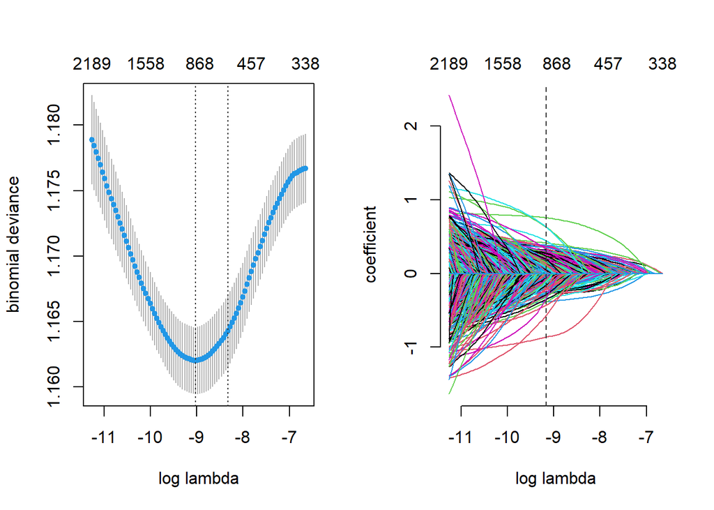

```r
par(mfrow=c(1,2))
plot(cv.nhlreg)
plot(cv.nhlreg$gamlr) ## cv.gamlr has included a gamlr object into cv.nhlreg
```

### 1.1.5 Lambda Selection

```r
log(nhlreg$lambda[which.min(AICc(nhlreg))])
```

```
##     seg55
## -9.165555
```

```r
log(nhlreg$lambda[which.min(AIC(nhlreg))])
```

```
##     seg55
## -9.165555
```

```r
log(nhlreg$lambda[which.min(BIC(nhlreg))])
```

```
##      seg1
## -6.653644
```

```r
log(cv.nhlreg$lambda.min)
```

```
## [1] -9.026004
```

```r
log(cv.nhlreg$lambda.1se)
```

```
## [1] -8.328251
```

AIC and AICc give exactly the same answer here (n>>df) and both are close to the `cv.min` answer.

```r
Bcvmin <- coef(cv.nhlreg, select="min")[colnames(player),]
sum(Bcvmin!=0) # around 600
```

```
## [1] 569
```

```r
exp(sort(Bcvmin,decreasing=TRUE)[1:10]) # similar top 10
```

```
##  PETER_FORSBERG    ONDREJ_PALAT   TYLER_TOFFOLI   SIDNEY_CROSBY  ZIGMUND_PALFFY
##        2.102627        1.753723        1.739178        1.495643        1.480726
##    JOE_THORNTON   PAVEL_DATSYUK   LOGAN_COUTURE       ERIC_FEHR ALEXANDER_SEMIN
##        1.456136        1.434733        1.421277        1.416317        1.410572
```

The 1se rule accounts for uncertainty about OOS error, and thus chooses a simpler model.

```r
Bcv1se <- coef(cv.nhlreg)[colnames(player),]
```

Even though log lambdas are close, df drops by 1/2

```r
sum(Bcv1se!=0) # only around 300
```

```
## [1] 267
```

Top 10 changes a bit as well

```r
exp(sort(Bcv1se,decreasing=TRUE)[1:10]) # top 10 changes a bit
```

```
##    PETER_FORSBERG     SIDNEY_CROSBY      JOE_THORNTON     PAVEL_DATSYUK
##          1.903021          1.400478          1.373408          1.326193
##   ALEXANDER_SEMIN LUBOMIR_VISNOVSKY     ALEX_OVECHKIN     LADISLAV_NAGY
##          1.320628          1.314965          1.297734          1.283936
##    MARIAN_GABORIK      RYAN_GETZLAF
##          1.276482          1.265935
```

BIC is way more (overly I think) conservative than all these options.

```r
Bbic <- coef(nhlreg,select=which.min(BIC(nhlreg)))[colnames(player),]
sum(Bbic!=0) # zero!  Nobody is different from average according to BIC
```

```
## [1] 0
```

The BIC is trying to find lambda with highest probability of having the minimum OOS error, which is subtly different than finding the lambda corresponding to lowest expected OOS error. For example, if there is more uncertainty about OOS error at the lambda with min expectation, then it could be that another value with higher expected error but lower uncertainty around this value will have a higher probability of being best. In this case, the BIC says there is much uncertainty at everything other than the null model, so that the null model ends up highest probability of being best.

As an aside: note that the null model here is not just an intercept, but rather includes onice configuration info along with information about the team and season. So the BIC is not saying that no players matter, but rather that it cannot confidently tell them apart from their team’s average level of play in a given season.

### 1.1.6 Comparing Model Selections

Finally, some plots to compare model selections

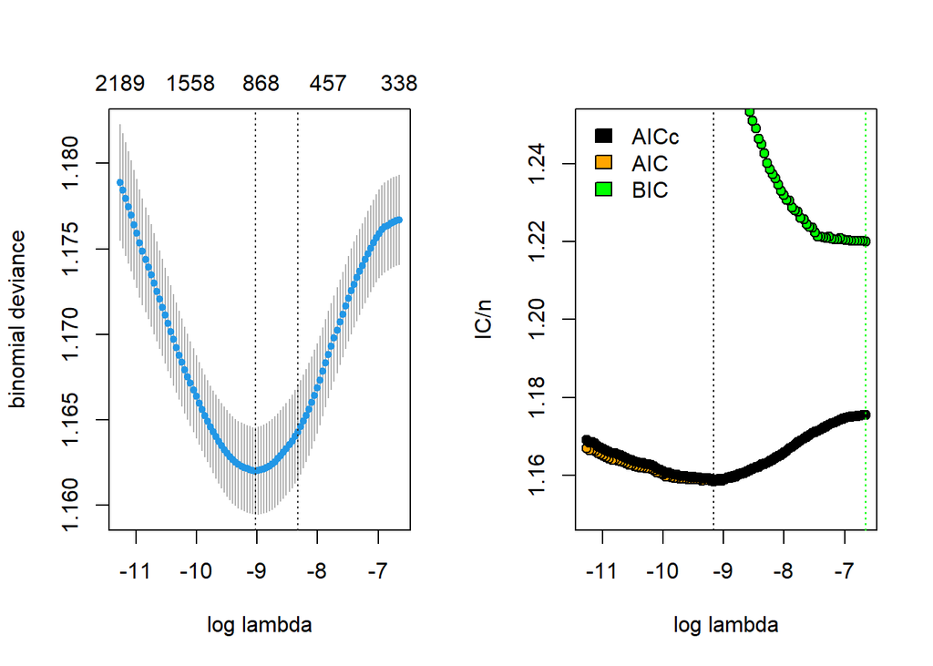

```r
ll <- log(nhlreg$lambda) ## the sequence of lambdas
n <- nrow(goal)
par(mfrow=c(1,2))
plot(cv.nhlreg)
plot(ll, AIC(nhlreg)/n,
    xlab="log lambda", ylab="IC/n", pch=21, bg="orange",ylim = c(1.15,1.25))
abline(v=ll[which.min(AIC(nhlreg))], col="orange", lty=3)
points(ll, AICc(nhlreg)/n, pch=21, bg="black")
abline(v=ll[which.min(AICc(nhlreg))], col="black", lty=3)
points(ll, BIC(nhlreg)/n, pch=21, bg="green")
abline(v=ll[which.min(BIC(nhlreg))], col="green", lty=3)

legend("topleft", bty="n",
    fill=c("black","orange","green"),legend=c("AICc","AIC","BIC"))
```

Plot all the answers along the path

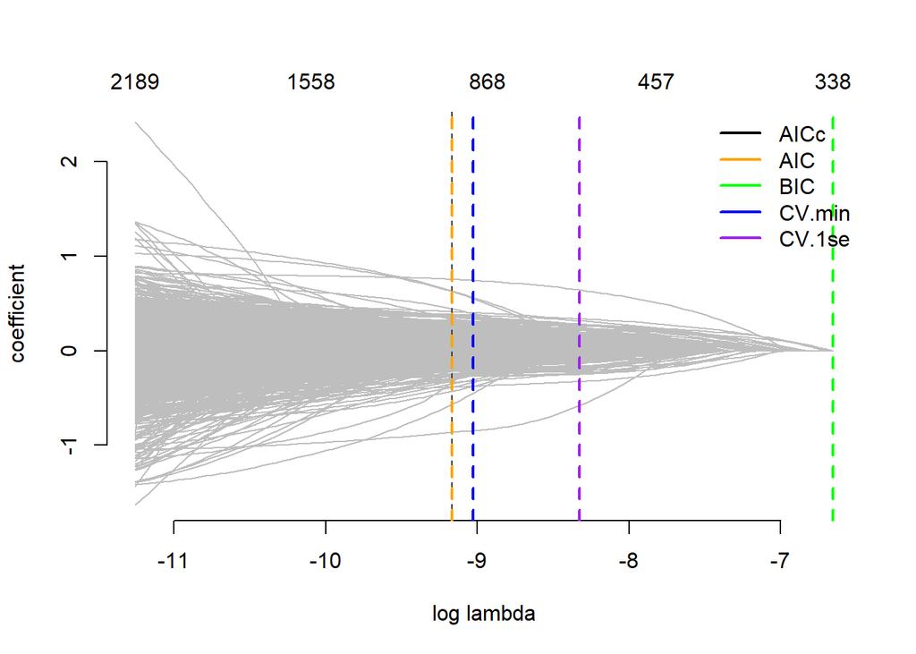

```r
par(mfrow=c(1,1))
plot(nhlreg, col="grey")
abline(v=ll[which.min(AICc(nhlreg))], col="black", lty=2, lwd=2)
abline(v=ll[which.min(AIC(nhlreg))], col="orange", lty=2, lwd=2)
abline(v=ll[which.min(BIC(nhlreg))], col="green", lty=2, lwd=2)
abline(v=log(cv.nhlreg$lambda.min), col="blue", lty=2, lwd=2)
abline(v=log(cv.nhlreg$lambda.1se), col="purple", lty=2, lwd=2)
legend("topright", bty="n", lwd=2,
    col=c("black","orange","green","blue","purple"),
    legend=c("AICc","AIC","BIC","CV.min","CV.1se"))
```

## 1.2 Browsing History

The table has three columns: [machine] id, site [id], [# of] visits

### 1.2.1 Data Mangement

```r
web <- read.csv("browser-domains.csv")
```

Read in the actual website names and relabel site factor

```r
sitenames <- scan("browser-sites.txt", what="character")
web$site <- factor(web$site, levels=1:length(sitenames), labels=sitenames)
```

also factor machine id

```r
web$id <- factor(web$id, levels=1:length(unique(web$id)))
```

Let’s get total visits per-machine and % of time on each site `tapply(a,b,c)` does `c(a)` for every level of factor `b`.

```r
machinetotals <- as.vector(tapply(web$visits,web$id,sum))
visitpercent <- 100*web$visits/machinetotals[web$id]
```

Since there are many sites that some people do not visit, our dataframe could blow out of proportion. We will first need to generate a sparse matrix.

```r
xweb <- sparseMatrix(
    i=as.numeric(web$id), j=as.numeric(web$site), x=visitpercent,
    dims=c(nlevels(web$id),nlevels(web$site)),
    dimnames=list(id=levels(web$id), site=levels(web$site)))
```

We can extract values from the sparse matrix. Ex: What sites did household 1 visit?

```r
xweb[1, xweb[1,]!=0]
```

```
##                   atdmt.com                   yahoo.com
##                  4.05202601                 11.85592796
##                     msn.com                  google.com
##                  0.25012506                  6.52826413
##                     aol.com          questionmarket.com
##                  0.15007504                  1.35067534
##   googlesyndication.com-o02             casalemedia.com
##                  3.40170085                  0.82541271
##             mywebsearch.com                 myspace.com
##                  0.10005003                  0.05002501
##               pointroll.com            yieldmanager.com
##                  0.72536268                  0.65032516
##                    live.com               mediaplex.com
##                  0.02501251                  0.32516258
##          precisionclick.com            tribalfusion.com
##                  0.15007504                  0.52526263
##        insightexpressai.com               trafficmp.com
##                  0.65032516                  0.30015008
##                    ebay.com               realmedia.com
##                  1.97598799                  0.52526263
##                    zedo.com             advertising.com
##                  0.62531266                  0.40020010
##               microsoft.com                  hotbar.com
##                  0.57528764                  0.02501251
##              adrevolver.com                     ru4.com
##                  0.35017509                  0.27513757
##                  nextag.com                overture.com
##                  1.67583792                  0.07503752
##                starware.com       relevantknowledge.com
##                  0.10005003                  2.37618809
##                   myway.com          partner2profit.com
##                  1.12556278                  2.92646323
##                   ditto.com                kanoodle.com
##                  0.07503752                  0.20010005
##             ebayobjects.com                 comcast.net
##                  1.35067534                  0.07503752
##               fastclick.net                 adbrite.com
##                  0.57528764                  0.50025013
##         vpptechnologies.com           specificclick.net
##                  0.05002501                  0.32516258
```

[output cut: 247 more lines]

```
##                  0.02501251                  0.02501251
##           jacquielawson.com                   atomz.com
##                  0.05002501                  0.05002501
##                   topix.net               mybloglog.com
##                  0.07503752                  0.02501251
##                    away.com                    grab.com
##                  0.02501251                  0.02501251
##                     pbs.org                business.com
##                  0.12506253                  0.02501251
##          myinsiderdeals.com                homegain.com
##                  0.02501251                  0.02501251
##            findarticles.com             cursormania.com
##                  0.10005003                  0.02501251
##     thebreastcancersite.com                     cox.com
##                  0.05002501                  0.02501251
```

Read in the spending data

```r
yspend <- read.csv("browser-totalspend.csv", row.names=1)  # use 1st column as row names
yspend <- as.matrix(yspend) ## good practice to move from dataframe to matrix
```

### 1.2.2 LASSO

```r
spender <- gamlr(xweb, log(yspend), verb=TRUE)
```

```
## *** n=10000 observations and p=1000 covariates ***
## segment 1: lambda = 0.2325, dev = 2.783e+04, npass = 0
## segment 2: lambda = 0.2219, dev = 2.778e+04, npass = 3
## segment 3: lambda = 0.2118, dev = 2.774e+04, npass = 3
## segment 4: lambda = 0.2022, dev = 2.77e+04, npass = 3
## segment 5: lambda = 0.193, dev = 2.766e+04, npass = 3
## segment 6: lambda = 0.1842, dev = 2.76e+04, npass = 3
## segment 7: lambda = 0.1759, dev = 2.753e+04, npass = 4
## segment 8: lambda = 0.1679, dev = 2.744e+04, npass = 5
## segment 9: lambda = 0.1602, dev = 2.733e+04, npass = 5
## segment 10: lambda = 0.153, dev = 2.72e+04, npass = 5
## segment 11: lambda = 0.146, dev = 2.708e+04, npass = 5
## segment 12: lambda = 0.1394, dev = 2.697e+04, npass = 5
## segment 13: lambda = 0.133, dev = 2.687e+04, npass = 5
## segment 14: lambda = 0.127, dev = 2.676e+04, npass = 5
## segment 15: lambda = 0.1212, dev = 2.663e+04, npass = 5
## segment 16: lambda = 0.1157, dev = 2.65e+04, npass = 5
## segment 17: lambda = 0.1104, dev = 2.639e+04, npass = 5
## segment 18: lambda = 0.1054, dev = 2.628e+04, npass = 5
## segment 19: lambda = 0.1006, dev = 2.616e+04, npass = 5
## segment 20: lambda = 0.09606, dev = 2.605e+04, npass = 5
## segment 21: lambda = 0.09169, dev = 2.595e+04, npass = 5
## segment 22: lambda = 0.08753, dev = 2.584e+04, npass = 5
## segment 23: lambda = 0.08355, dev = 2.574e+04, npass = 4
## segment 24: lambda = 0.07975, dev = 2.564e+04, npass = 4
## segment 25: lambda = 0.07613, dev = 2.553e+04, npass = 4
## segment 26: lambda = 0.07267, dev = 2.543e+04, npass = 4
## segment 27: lambda = 0.06936, dev = 2.532e+04, npass = 4
## segment 28: lambda = 0.06621, dev = 2.522e+04, npass = 4
## segment 29: lambda = 0.0632, dev = 2.511e+04, npass = 4
## segment 30: lambda = 0.06033, dev = 2.501e+04, npass = 4
## segment 31: lambda = 0.05759, dev = 2.491e+04, npass = 4
## segment 32: lambda = 0.05497, dev = 2.481e+04, npass = 4
## segment 33: lambda = 0.05247, dev = 2.47e+04, npass = 4
## segment 34: lambda = 0.05009, dev = 2.46e+04, npass = 4
## segment 35: lambda = 0.04781, dev = 2.449e+04, npass = 5
## segment 36: lambda = 0.04564, dev = 2.438e+04, npass = 5
## segment 37: lambda = 0.04356, dev = 2.427e+04, npass = 6
## segment 38: lambda = 0.04158, dev = 2.416e+04, npass = 6
## segment 39: lambda = 0.03969, dev = 2.405e+04, npass = 6
```

[output cut: 46 more lines]

```
## segment 86: lambda = 0.004459, dev = 2.109e+04, npass = 8
## segment 87: lambda = 0.004256, dev = 2.107e+04, npass = 8
## segment 88: lambda = 0.004063, dev = 2.105e+04, npass = 8
## segment 89: lambda = 0.003878, dev = 2.103e+04, npass = 7
## segment 90: lambda = 0.003702, dev = 2.102e+04, npass = 7
## segment 91: lambda = 0.003533, dev = 2.1e+04, npass = 7
## segment 92: lambda = 0.003373, dev = 2.098e+04, npass = 7
## segment 93: lambda = 0.00322, dev = 2.097e+04, npass = 6
## segment 94: lambda = 0.003073, dev = 2.095e+04, npass = 6
## segment 95: lambda = 0.002934, dev = 2.094e+04, npass = 6
## segment 96: lambda = 0.0028, dev = 2.093e+04, npass = 6
## segment 97: lambda = 0.002673, dev = 2.091e+04, npass = 6
## segment 98: lambda = 0.002551, dev = 2.09e+04, npass = 5
## segment 99: lambda = 0.002435, dev = 2.089e+04, npass = 5
## segment 100: lambda = 0.002325, dev = 2.088e+04, npass = 5
```

```r
summary(spender)
```

```
##
## gaussian gamlr with 1000 inputs and 100 segments.
```

```
##             lambda par  df          r2      aicc
## seg1   0.232476092   1   1 0.000000000 10236.678
## seg2   0.221909695   2   2 0.001725303 10221.411
## seg3   0.211823557   2   2 0.003297334 10205.651
## seg4   0.202195849   2   2 0.004729710 10191.270
## seg5   0.193005736   2   2 0.006034838 10178.148
## seg6   0.184233327   3   3 0.008059419 10159.760
## seg7   0.175859638   5   5 0.010759747 10136.503
## seg8   0.167866546   7   7 0.013978241 10107.920
## seg9   0.160236753  10  10 0.018051482 10072.536
## seg10  0.152953745  11  11 0.022568088 10028.438
## seg11  0.146001761  12  12 0.026834473  9986.698
## seg12  0.139365756  12  12 0.030824198  9945.617
## seg13  0.133031367  13  13 0.034577333  9908.822
## seg14  0.126984886  16  16 0.038557614  9873.526
## seg15  0.121213227  18  18 0.043190423  9829.238
## seg16  0.115703899  18  18 0.047623601  9782.797
## seg17  0.110444978  18  18 0.051662879  9740.294
## seg18  0.105425083  21  21 0.055664541  9704.032
## seg19  0.100633351  22  22 0.059819719  9661.943
## seg20  0.096059410  24  24 0.063739653  9624.181
## seg21  0.091693361  25  25 0.067595723  9584.920
## seg22  0.087525756  28  28 0.071296509  9551.183
## seg23  0.083547576  31  31 0.074986542  9517.407
## seg24  0.079750209  31  31 0.078668776  9477.520
## seg25  0.076125439  37  37 0.082487125  9448.073
## seg26  0.072665421  40  40 0.086306440  9412.407
## seg27  0.069362665  42  42 0.090037319  9375.524
## seg28  0.066210025  49  49 0.093679230  9349.550
## seg29  0.063200677  54  54 0.097580298  9316.519
## seg30  0.060328109  54  54 0.101267227  9275.580
## seg31  0.057586103  58  58 0.104923128  9242.910
## seg32  0.054968726  63  63 0.108525962  9212.700
## seg33  0.052470312  68  68 0.112302698  9180.378
## seg34  0.050085456  79  79 0.116044277  9160.469
## seg35  0.047808994  87  87 0.119877269  9133.283
## seg36  0.045636002  92  92 0.123789610  9098.915
## seg37  0.043561775 101 101 0.127898571  9070.264
## seg38  0.041581825 108 108 0.131909537  9038.465
## seg39  0.039691867 115 115 0.135762390  9008.302
```

[output cut: 46 more lines]

```
## seg86  0.004458683 738 738 0.242015972  9057.529
## seg87  0.004256029 747 747 0.242766854  9068.623
## seg88  0.004062586 760 760 0.243477983  9089.641
## seg89  0.003877935 773 773 0.244149588  9111.259
## seg90  0.003701677 786 786 0.244792248  9133.338
## seg91  0.003533430 800 800 0.245411685  9158.168
## seg92  0.003372830 809 809 0.245997670  9171.689
## seg93  0.003219530 820 820 0.246538742  9190.588
## seg94  0.003073197 827 827 0.247066267  9200.212
## seg95  0.002933516 830 830 0.247559945  9200.787
## seg96  0.002800183 841 841 0.248026092  9220.787
## seg97  0.002672910 849 849 0.248465108  9234.039
## seg98  0.002551422 855 855 0.248856592  9243.170
## seg99  0.002435456 867 867 0.249232707  9266.900
## seg100 0.002324761 873 873 0.249589392  9276.545
```

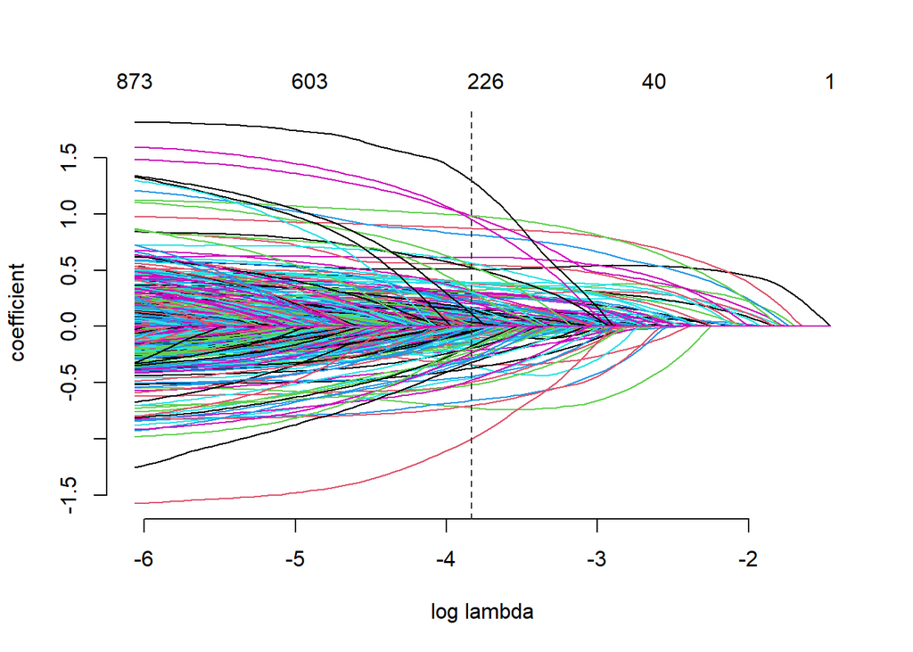

```r
plot(spender) ## path plot
```

### 1.2.3 Extracting and observing coefficients

**DO NOT GO TO THESE LINKS**

```r
B <- coef(spender) ## the coefficients selected under AICc

B <- B[-1,] # drop intercept and remove STM formatting
B[which.min(B)] ## low spenders spend a lot of time here
```

```
## cursormania.com
##       -0.998143
```

```r
B[which.max(B)] ## big spenders hang out here
```

```
## shopyourbargain.com
##            1.294246
```

#### 1.2.3.1 Extracting Coefficients Using Other Rules

```r
coef(spender, select=which.min(BIC(spender))) ## and BIC instead
```

[output not shown]

[output cut: 948 more lines]

[output not shown]

### 1.2.4 Cross-Validation

```r
cv.spender <- cv.gamlr(xweb, log(yspend), verb=TRUE,nfold =10)
```

```
## fold 1,2,3,4,5,6,7,8,9,10,done.
```

```r
beta1se <- coef(cv.spender) ## 1se rule; see ?cv.gamlr
betamin <- coef(cv.spender, select="min") ## min cv selection
cbind(beta1se,betamin)[c("tvguide.com","americanexpress.com"),]
```

```
## 2 x 2 sparse Matrix of class "dgCMatrix"
##                          seg36       seg50
## tvguide.com         .          -0.01207381
## americanexpress.com 0.04230693  0.04869937
```

#### 1.2.4.1 Ploting CV Results

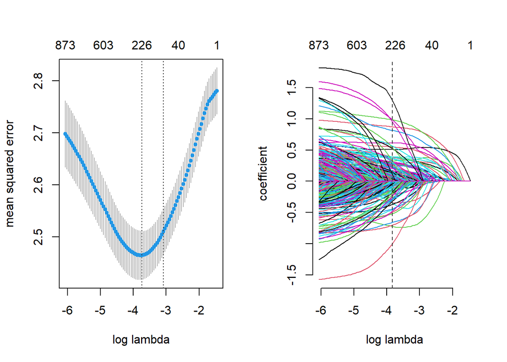

```r
par(mfrow=c(1,2))
plot(cv.spender)
plot(cv.spender$gamlr) ## cv.gamlr includes a gamlr object
```

#### 1.2.4.2 Log lambdas selected under various criteria

```r
log(spender$lambda[which.min(AICc(spender))])
```

```
##     seg52
## -3.831328
```

```r
log(spender$lambda[which.min(AIC(spender))])
```

```
##     seg62
## -4.296497
```

```r
log(spender$lambda[which.min(BIC(spender))])
```

```
##     seg31
## -2.854474
```

```r
log(cv.spender$lambda.min)
```

```
## [1] -3.738295
```

```r
log(cv.spender$lambda.1se)
```

```
## [1] -3.087058
```

### 1.2.5 All Metrics, together in a path plot.

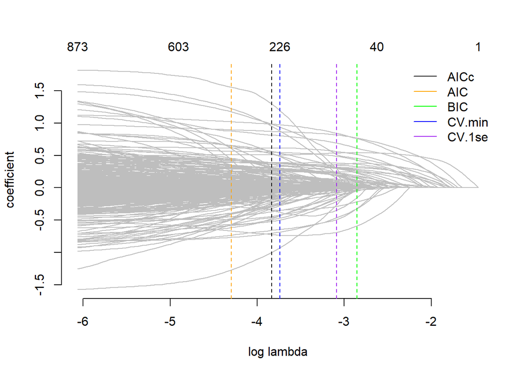

```r
ll <- log(spender$lambda)

plot(spender, col="grey")
abline(v=ll[which.min(AICc(spender))], col="black", lty=2)
abline(v=ll[which.min(AIC(spender))], col="orange", lty=2)
abline(v=ll[which.min(BIC(spender))], col="green", lty=2)
abline(v=log(cv.spender$lambda.min), col="blue", lty=2)
abline(v=log(cv.spender$lambda.1se), col="purple", lty=2)
legend("topright", bty="n", lwd=1,
    col=c("black","orange","green","blue","purple"),
    legend=c("AICc","AIC","BIC","CV.min","CV.1se"))
```